# Experiment 3

2024-12-21

## Children leverage the Successor Representation for reward-guided choice

### Exclusion Criteria

Participants were excluded for >20 browser interactions, >3 comprehension errors, >10 timeouts, or mean RT >5000ms

```r
exclusions_data <- read_csv("../data/preprocessed/excluded.csv")

criteria <- list(
  broswer_interact = function(df) df$browser_interactions > 20,
  timeouts = function(df) df$missed_trials > 10,
  comprehension_error = function(df) df$comp_retries > 3,
  mean_rt = function(df) df$avg_rt > 5000
)

criteria_counts <- data.frame(
  Criteria = character(length(criteria)),
  Count = integer(length(criteria)))

for (i in seq_along(criteria)) {
  # Get the criterion function
  criterion_name <- names(criteria)[i]
  criterion <- criteria[[i]]
  # Apply the criterion to count the number of rows
  count <- sum(criterion(exclusions_data))
  criteria_counts[i, "Criteria"] <- criterion_name
  criteria_counts[i, "Count"] <- count
  exclusions_data <- exclusions_data[!criterion(exclusions_data), ]
}

criteria_counts
```

```
##              Criteria Count
## 1    broswer_interact     0
## 2            timeouts     0
## 3 comprehension_error     9
## 4             mean_rt     0
```

### Loading Full Dataset

Reading in preprocessed dataset. Each row represents a traversal trial and its preceeding shop-only trial. All continuous variables are z-scored

- **action1TowardsPrevEnd** (1 or 0; 1 corresponds to taking action1 towards island containing prior shop; 0 is other island).
- **prior_reward** (1 or 0; 1 corresponds to reward on prior shop trial).
- **shop_neighbor_prior_reward** (1 or 0, corresponds to reward when the neighbor to the prior shop was last seen in traversal or shop-only).
- **prior_shop_choice** (1 or 0, 1 if prior shop was chosen on last visit to its island).

```r
data <- read_csv("../data/preprocessed/data.csv")
scale_this <- function(x){
  (x - mean(x, na.rm=TRUE)) / sd(x, na.rm=TRUE)
}
data$shop_neighbor_prior_reward <- scale_this(data$shop_neighbor_prior_reward)
data$prior_shop_choice <- scale_this(data$prior_shop_choice)
data$prior_reward <- scale_this(data$prior_reward)
data$prior_island_reward <- scale_this(data$prior_island_reward)
data$sub <- factor(data$sub)
data$age <- scale_this(data$age)
data$categorical_age <- factor(data$categorical_age, levels = c('Children', 'Adolescents', 'Adults'))

# Filter data for analyses on children only
child_only_data <- data[data$categorical_age == 'Children',]
```

### Participants leveraged mental models to guide choice

A significant effect of **prior_reward** on island choice would suggest influence of prior shop trial on traversal trial island choice in a model-based or SR-dependent manner

```r
reward_only <- glmer(action1TowardsPrevEnd ~ prior_reward * age + (prior_reward | sub),
                     data = data,
                     family = binomial)
my_tab_model(reward_only)
```

|  | action1TowardsPrevEnd |  |  |  |
| --- | --- | --- | --- | --- |
| Predictors | Log-Odds | CI | z | p > \|z\| |
| (Intercept) | 0.11 | 0.08 – 0.15 | 6.23 | **<0.001** |
| prior reward | 0.19 | 0.15 – 0.22 | 10.07 | **<0.001** |
| age | 0.01 | -0.03 – 0.04 | 0.41 | 0.679 |
| prior reward × age | 0.01 | -0.02 – 0.05 | 0.74 | 0.460 |

### Unique signatures of MB and SR-based decision strategies

- Significant effect of **prior_reward** would suggest influence of prior shop trial on traversal trial island choice in a model-based or SR-dependent manner.
- Significant **prior_shop_choice * prior_reward** interaction indicates SR-dependent behavior, while **prior_reward * shop_neighbor_prior_reward** interaction indicates MB-behavior.

```r
mb_sr <- glmer(action1TowardsPrevEnd ~ prior_reward * shop_neighbor_prior_reward * prior_shop_choice * age + (prior_reward * shop_neighbor_prior_reward * prior_shop_choice | sub),
                     data = data,
                     family = binomial)
my_tab_model(mb_sr)
```

|  | action1TowardsPrevEnd |  |  |  |
| --- | --- | --- | --- | --- |
| Predictors | Log-Odds | CI | z | p > \|z\| |
| (Intercept) | 0.03 | -0.01 – 0.07 | 1.57 | 0.117 |
| prior reward | 0.25 | 0.21 – 0.29 | 11.53 | **<0.001** |
| shop neighbor prior reward | 0.21 | 0.17 – 0.24 | 11.00 | **<0.001** |
| prior shop choice | 0.03 | 0.00 – 0.05 | 1.98 | **0.048** |
| age | -0.01 | -0.05 – 0.03 | -0.43 | 0.667 |
| prior reward × shop neighbor prior reward | -0.11 | -0.14 – -0.08 | -6.78 | **<0.001** |
| prior reward × prior shop choice | 0.12 | 0.08 – 0.15 | 6.72 | **<0.001** |
| shop neighbor prior reward × prior shop choice | -0.28 | -0.32 – -0.24 | -13.24 | **<0.001** |
| prior reward × age | 0.02 | -0.02 – 0.06 | 0.85 | 0.396 |
| shop neighbor prior reward × age | 0.03 | -0.01 – 0.07 | 1.55 | 0.121 |
| prior shop choice × age | 0.00 | -0.02 – 0.03 | 0.18 | 0.853 |
| (prior reward × shop neighbor prior reward) × prior shop choice | 0.06 | 0.03 – 0.09 | 4.35 | **<0.001** |
| (prior reward × shop neighbor prior reward) × age | -0.03 | -0.06 – 0.01 | -1.61 | 0.107 |
| (prior reward × prior shop choice) × age | 0.03 | -0.01 – 0.06 | 1.67 | 0.094 |
| (shop neighbor prior reward × prior shop choice) × age | -0.07 | -0.11 – -0.02 | -3.13 | **0.002** |
| (prior reward × shop neighbor prior reward × prior shop choice) × age | -0.00 | -0.03 – 0.03 | -0.06 | 0.952 |

### Refitting with child data only to see if there is still evidence for use of MB and SR strategies

```r
child_only_mb_sr <- glmer(action1TowardsPrevEnd ~ prior_reward * shop_neighbor_prior_reward * prior_shop_choice + (prior_reward * shop_neighbor_prior_reward * prior_shop_choice | sub),
                     data = child_only_data,
                     family = binomial)
my_tab_model(child_only_mb_sr)
```

|  | action1TowardsPrevEnd |  |  |  |
| --- | --- | --- | --- | --- |
| Predictors | Log-Odds | CI | z | p > \|z\| |
| (Intercept) | 0.03 | -0.05 – 0.10 | 0.73 | 0.466 |
| prior reward | 0.24 | 0.18 – 0.31 | 7.40 | **<0.001** |
| shop neighbor prior reward | 0.20 | 0.14 – 0.26 | 6.64 | **<0.001** |
| prior shop choice | 0.01 | -0.04 – 0.06 | 0.26 | 0.797 |
| prior reward × shop neighbor prior reward | -0.10 | -0.15 – -0.05 | -3.69 | **<0.001** |
| prior reward × prior shop choice | 0.09 | 0.03 – 0.15 | 3.15 | **0.002** |
| shop neighbor prior reward × prior shop choice | -0.21 | -0.28 – -0.14 | -5.64 | **<0.001** |
| (prior reward × shop neighbor prior reward) × prior shop choice | 0.05 | 0.00 – 0.10 | 2.10 | **0.036** |

### Plots for SR and MB interactions

```r
# recoding variables as factors for plotting
data$prior_reward <- factor(data$prior_reward, labels=c("No Reward","Reward"))
data$shop_neighbor_prior_reward <- factor(data$shop_neighbor_prior_reward, labels=c("No Reward","Reward"))
data$prior_shop_choice <- factor(data$prior_shop_choice, labels=c("Neighboring","Observed"))
data$prior_island_reward <- factor(data$prior_island_reward, labels=c("No Reward","Reward"))
data$block_change_congruent <- factor(data$block_change_congruent, labels=c("Incongruent","Congruent"))
```

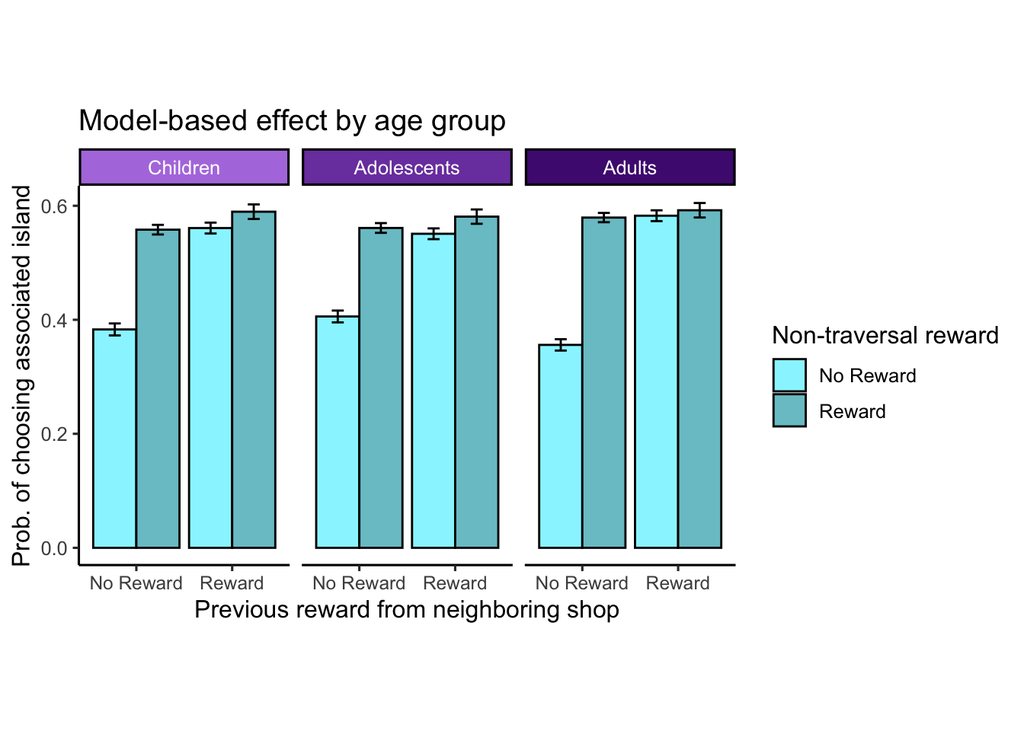

```r
summary_data <- summarySE(data, measurevar="action1TowardsPrevEnd",
                        groupvars=c("shop_neighbor_prior_reward","prior_reward","sub","categorical_age"))
summary_data <- summarySE(data, measurevar="action1TowardsPrevEnd",
                        groupvars=c("shop_neighbor_prior_reward","prior_reward","categorical_age"))
strip <- strip_themed(background_x = elem_list_rect(fill = c("#B27EE0","#7c44ad", "#501b80")),text_x=list(element_text(colour = "white")))

ggplot(summary_data, aes(x = shop_neighbor_prior_reward, y = action1TowardsPrevEnd, fill = prior_reward)) +
  facet_wrap2(~ categorical_age, strip=strip) +
  geom_bar(stat = "identity", position = "dodge", colour="black") +
  geom_errorbar(aes(ymin = action1TowardsPrevEnd - se, ymax = action1TowardsPrevEnd + se),
                position = position_dodge(width = 0.9), width = 0.25) +
  labs(title = "Model-based effect by age group",
       x = "Previous reward from neighboring shop",
       y = "Prob. of choosing associated island") +
  scale_fill_manual(name = "Non-traversal reward", values=c("cadetblue1","cadetblue3")) +
  theme_classic(base_size = 12) +
  theme(axis.text.x=element_text(size=9.2), aspect.ratio=9/5)
```

```r
ggsave("figures/experiment3_mb.png")
```

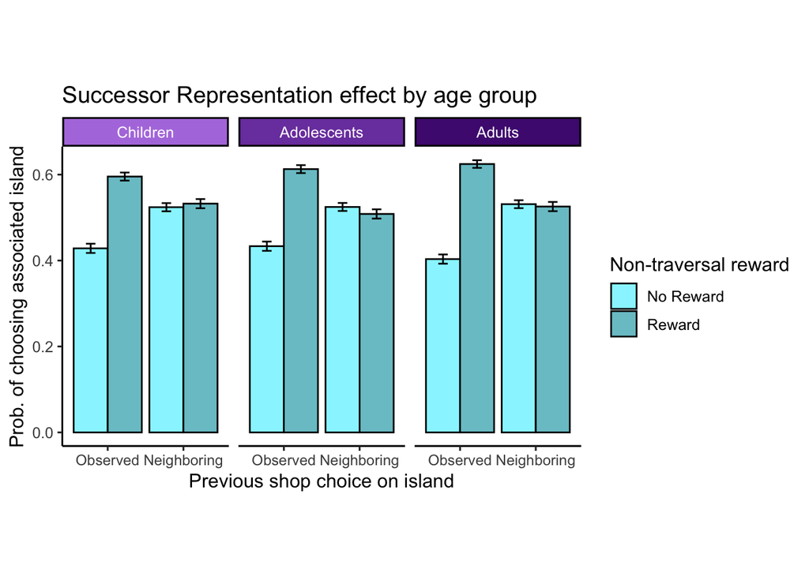

```r
summary_data <- summarySE(data, measurevar="action1TowardsPrevEnd",
                        groupvars=c("prior_shop_choice","prior_reward","sub","categorical_age"))
summary_data <- summarySE(data, measurevar="action1TowardsPrevEnd",
                        groupvars=c("prior_shop_choice","prior_reward","categorical_age"))

ggplot(summary_data, aes(x = prior_shop_choice, y = action1TowardsPrevEnd, fill = prior_reward)) +
  geom_bar(stat = "identity", position = "dodge", colour="black") +
  geom_errorbar(aes(ymin = action1TowardsPrevEnd - se, ymax = action1TowardsPrevEnd + se),
                position = position_dodge(width = 0.9), width = 0.25) +
  labs(title = "Successor Representation effect by age group",
       x = "Previous shop choice on island",
       y = "Prob. of choosing associated island") +
    scale_fill_manual(name = "Non-traversal reward", values=c("cadetblue1","cadetblue3")) +

  facet_wrap2(~ categorical_age, strip=strip) +
  theme_classic(base_size = 12) +
  theme(axis.text.x=element_text(size=9.2), aspect.ratio=9/5) +
  scale_x_discrete(limits=rev)
```

```r
ggsave("figures/experiment3_sr.png")
```